# report_addition_Switalska_Kohut.rmd

2023-12-08

# 3. EDA

## 3.2. Barplots

We can see that bar plots for different methods are very similar.

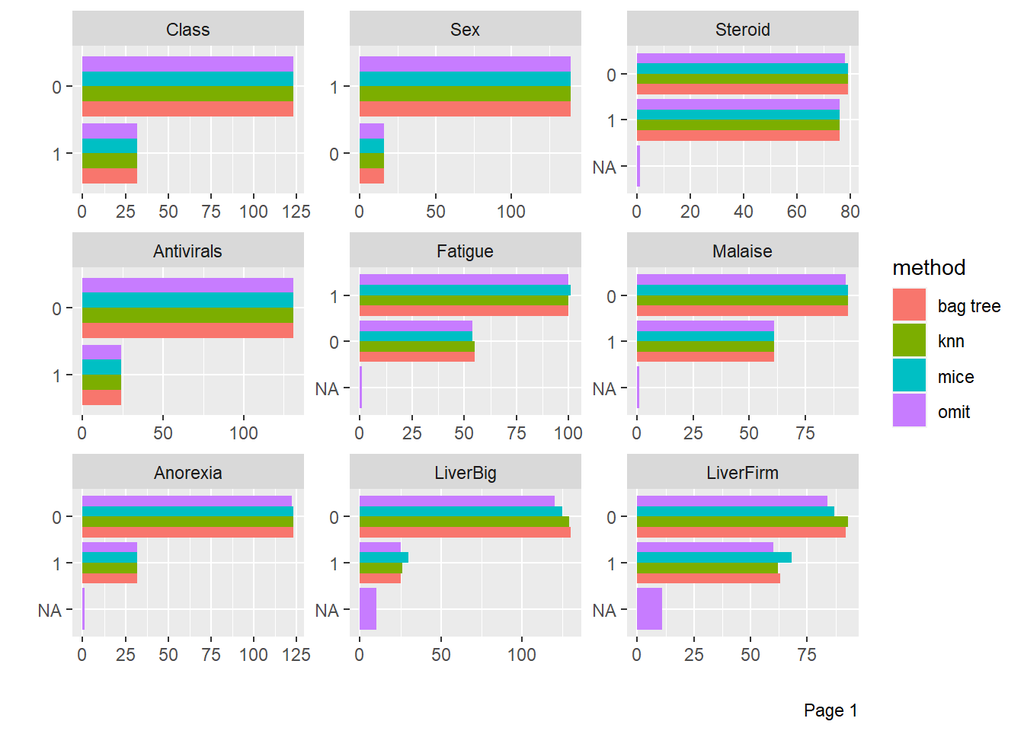

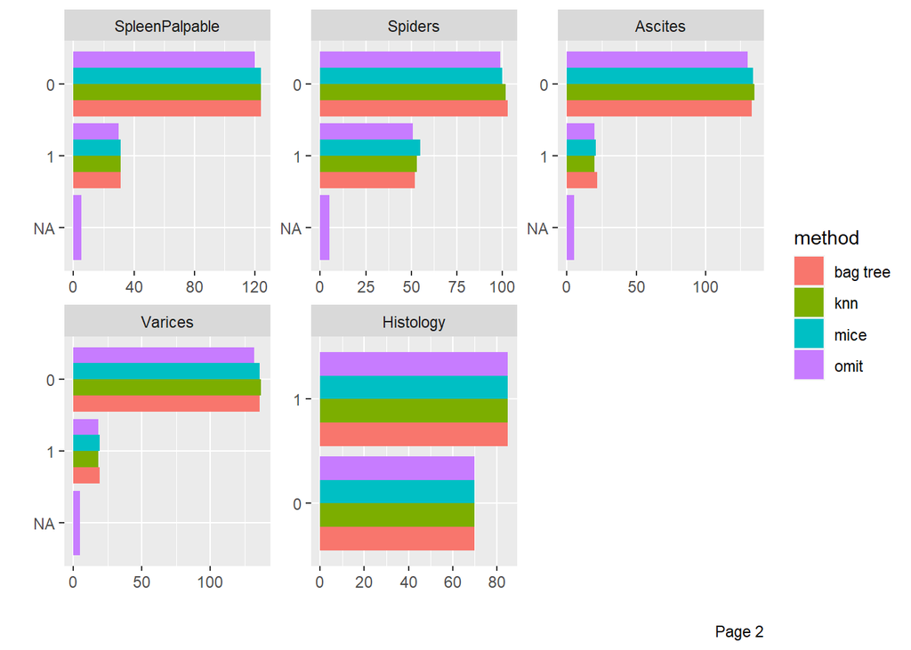

```r
plot_bar(df_all, by = "method", by_position = "dodge")
```

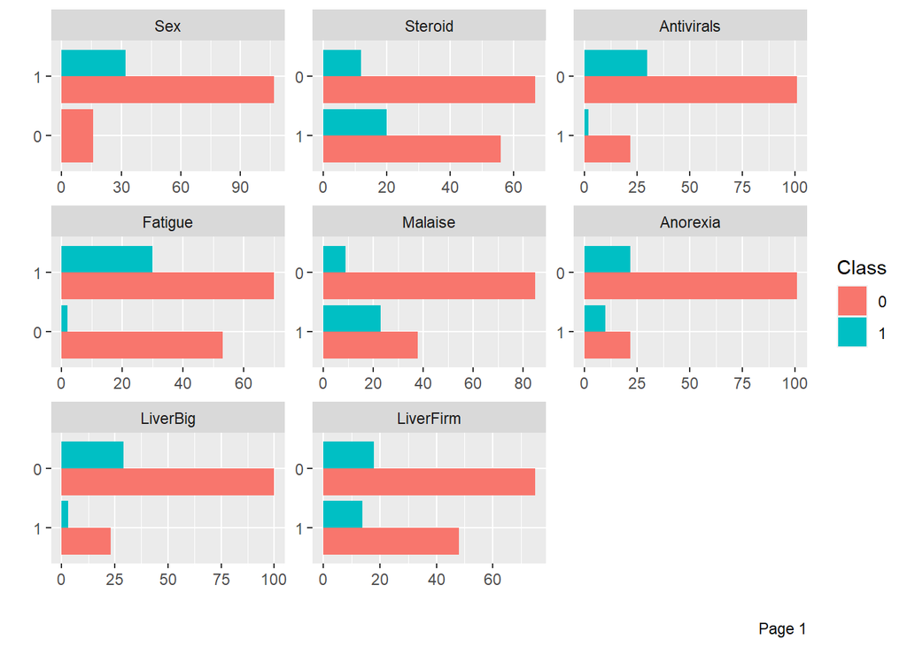

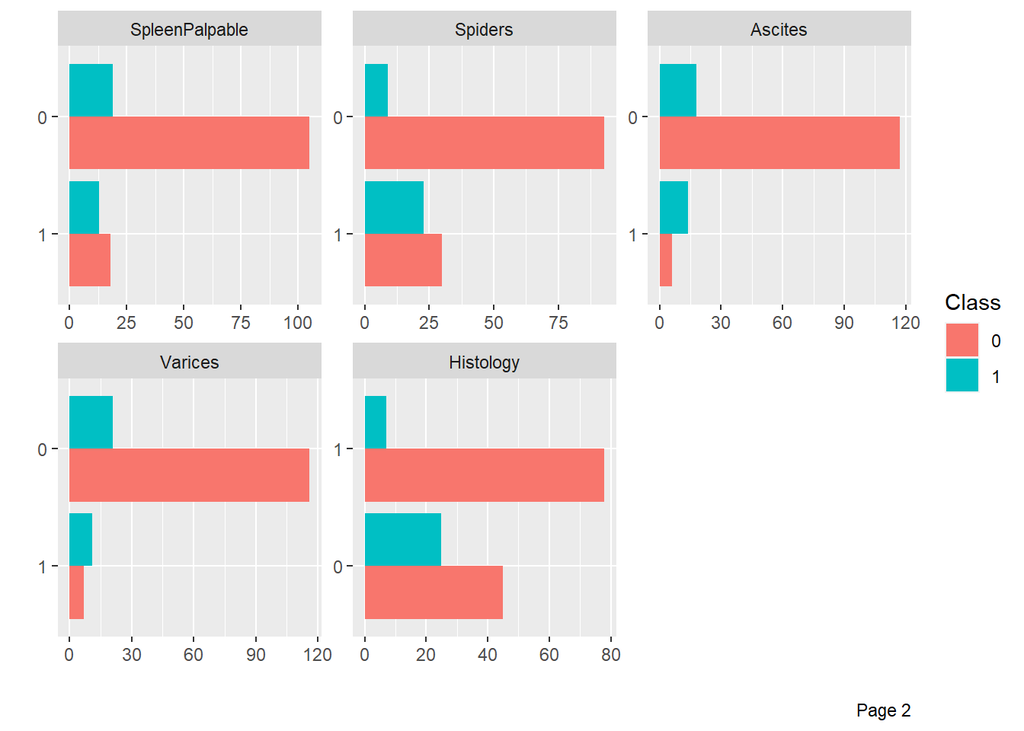

```r
df1[, categorical] <-  lapply(df1[, categorical], as.factor)
plot_bar(df1[-21], by = "Class", by_position = "dodge")
```

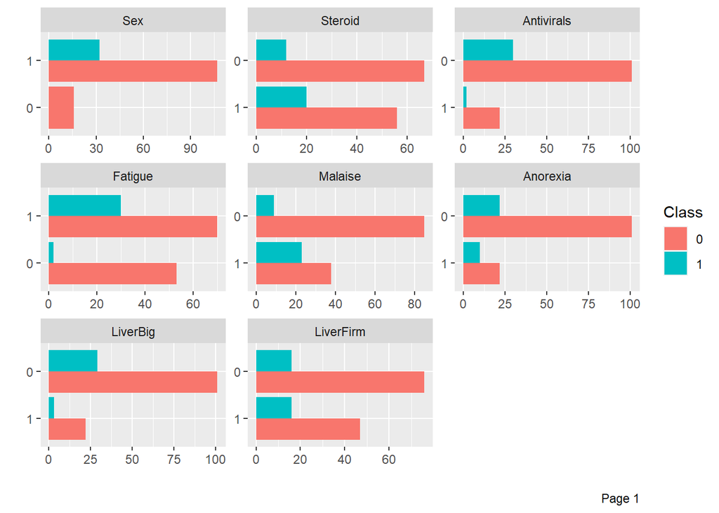

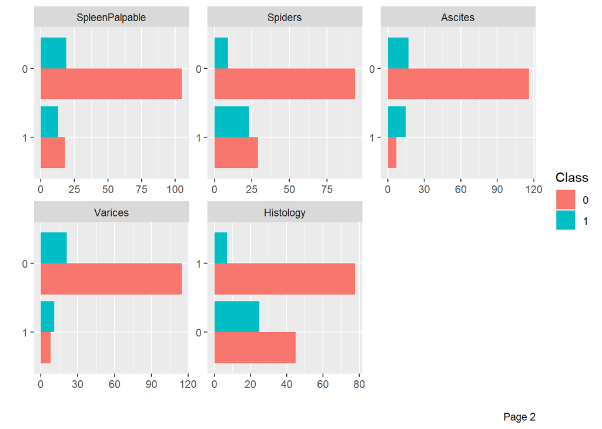

```r
df2[, categorical] <-  lapply(df2[, categorical], as.factor)
plot_bar(df2[-21], by = "Class", by_position = "dodge")
```

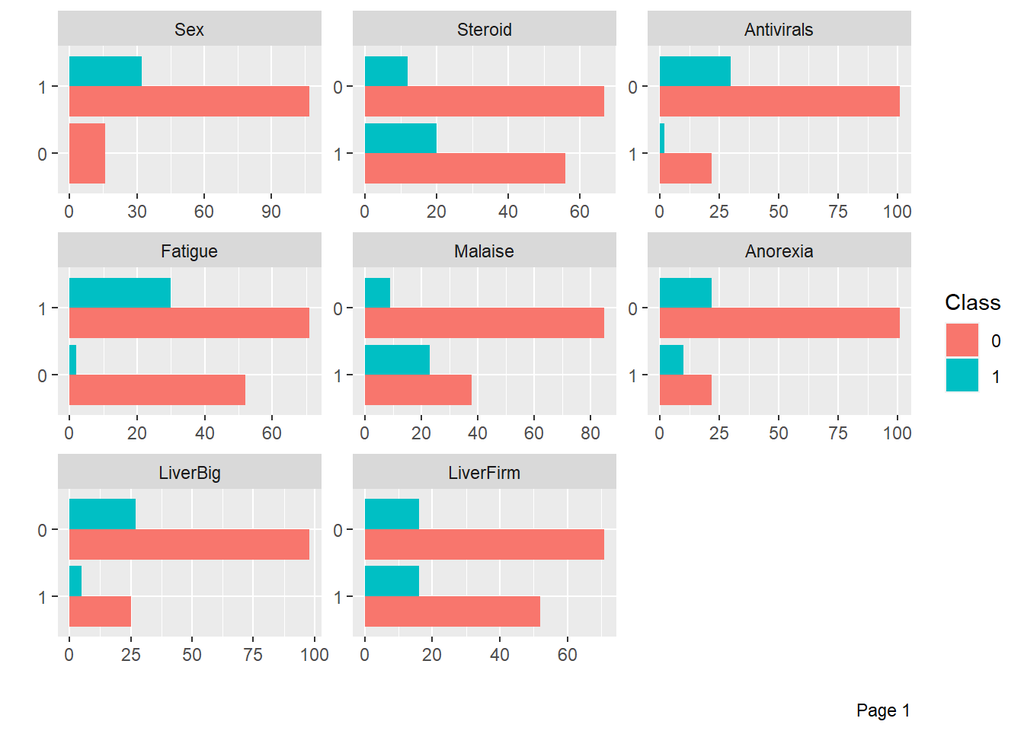

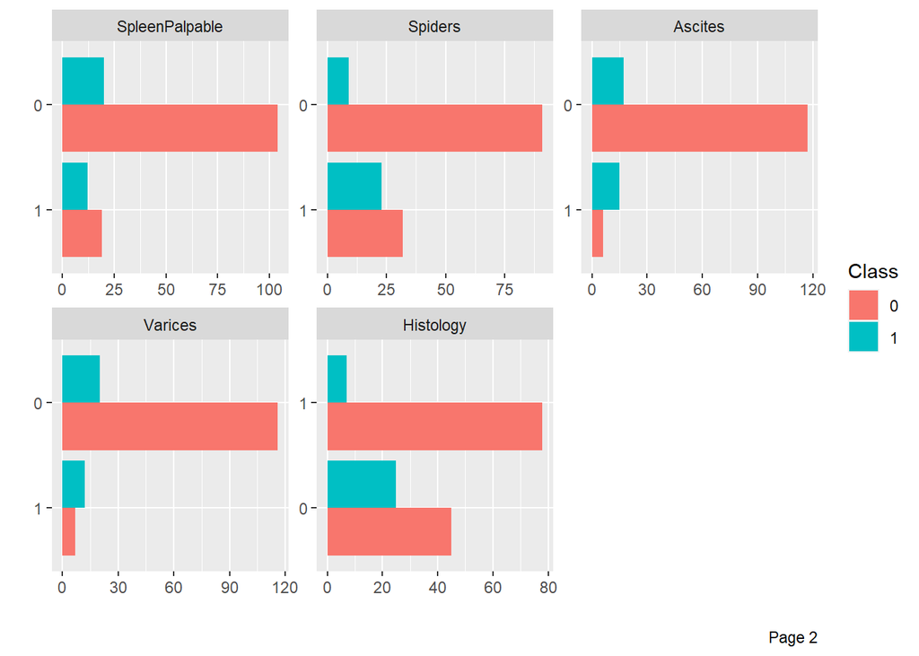

```r
df5[, categorical] <-  lapply(df5[, categorical], as.factor)
plot_bar(df5[-21], by = "Class", by_position = "dodge")
```

## 3.3. Histograms

We can see that density plots for different methods are very similar. Only for Protime results are a bit different.

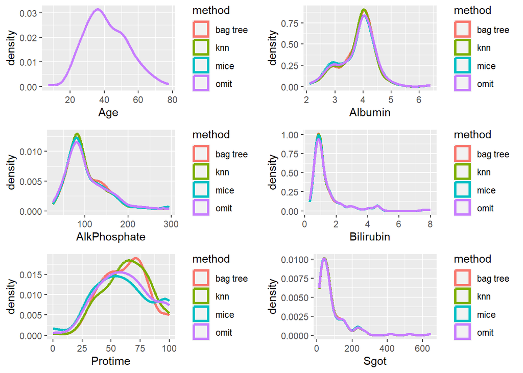

```r
p7 <- ggplot(df_all, aes(x = Age, color = method)) +
  scale_fill_brewer(palette = "Set2") +
  geom_density(size = 1.1)

p8 <- ggplot(df_all, aes(x = Albumin, color = method)) +
  scale_fill_brewer(palette = "Set2") +
  geom_density(size = 1.1)

p9 <- ggplot(df_all, aes(x = AlkPhosphate, color = method)) +
  scale_fill_brewer(palette = "Set2") +
  geom_density(size = 1.1)

p10 <- ggplot(df_all, aes(x = Bilirubin, color = method)) +
  scale_fill_brewer(palette = "Set2") +
  geom_density(size = 1.1)

p11 <- ggplot(df_all, aes(x = Protime, color = method)) +
  scale_fill_brewer(palette = "Set2") +
  geom_density(size = 1.1)

p12 <- ggplot(df_all, aes(x = Sgot, color = method)) +
  scale_fill_brewer(palette = "Set2") +
  geom_density(size = 1.1)

ggarrange(p7, p8, p9, p10, p11, p12, ncol = 2, nrow = 3)
```

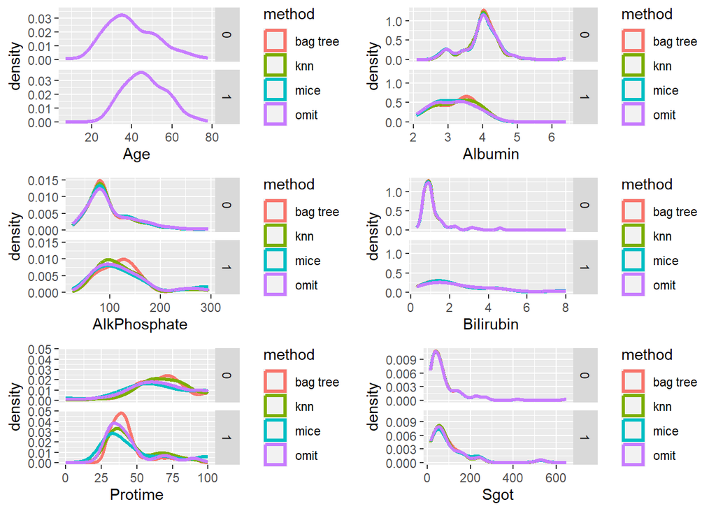

```r
p13 <- ggplot(df_all, aes(x = Age, color = method)) +
  scale_fill_brewer(palette = "Set2") +
  geom_density(size = 1.1) +
  facet_grid(Class ~ .)

p14 <- ggplot(df_all, aes(x = Albumin, color = method)) +
  scale_fill_brewer(palette = "Set2") +
  geom_density(size = 1.1) +
  facet_grid(Class ~ .)

p15 <- ggplot(df_all, aes(x = AlkPhosphate, color = method)) +
  scale_fill_brewer(palette = "Set2") +
  geom_density(size = 1.1) +
  facet_grid(Class ~ .)

p16 <- ggplot(df_all, aes(x = Bilirubin, color = method)) +
  scale_fill_brewer(palette = "Set2") +
  geom_density(size = 1.1) +
  facet_grid(Class ~ .)

p17 <- ggplot(df_all, aes(x = Protime, color = method)) +
  scale_fill_brewer(palette = "Set2") +
  geom_density(size = 1.1) +
  facet_grid(Class ~ .)

p18 <- ggplot(df_all, aes(x = Sgot, color = method)) +
  scale_fill_brewer(palette = "Set2") +
  geom_density(size = 1.1) +
  facet_grid(Class ~ .)

ggarrange(p13, p14, p15, p16, p17, p18, ncol = 2, nrow = 3)
```

## 3.4. Q-Q plot

We can see that Q-Q plots for different methods are very similar. Only for Protime results are a bit different.

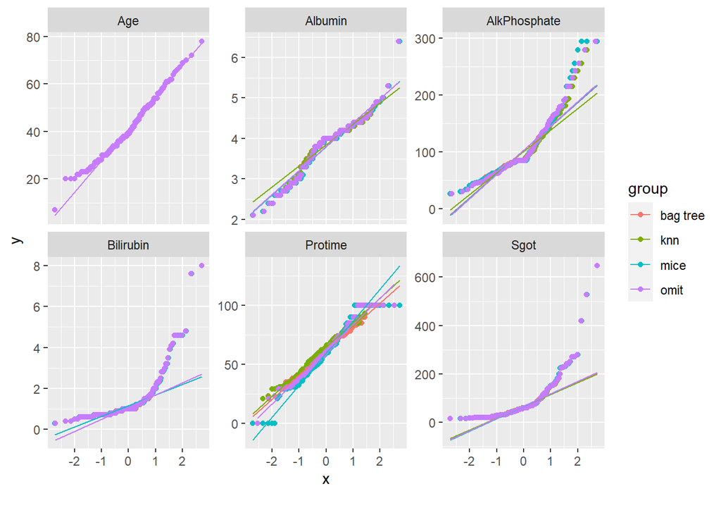

```r
plot_qq(df_all, by = "method")
```

## 3.5. Boxplots

We can see that bar plots for different methods are very similar.

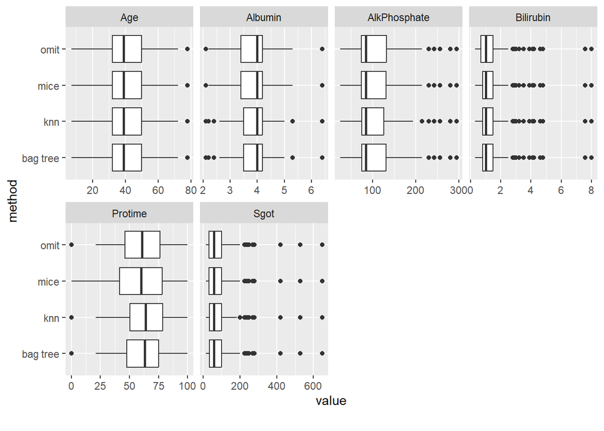

```r
plot_boxplot(df_all, by = "method")
```

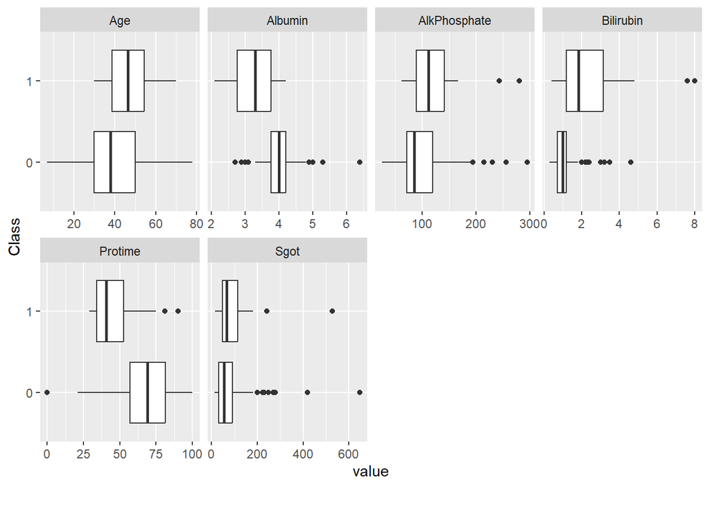

```r
plot_boxplot(df1, by = "Class")
```

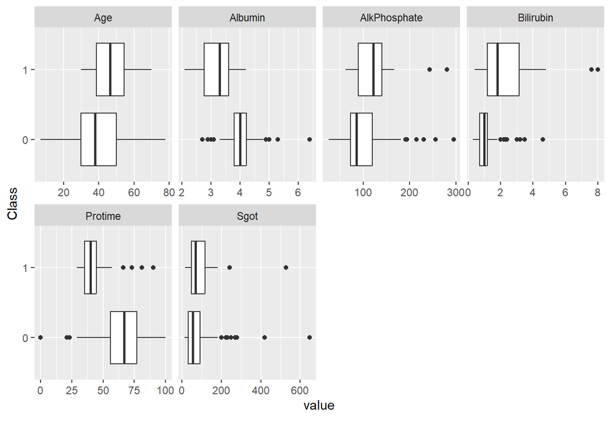

```r
plot_boxplot(df2, by = "Class")
```

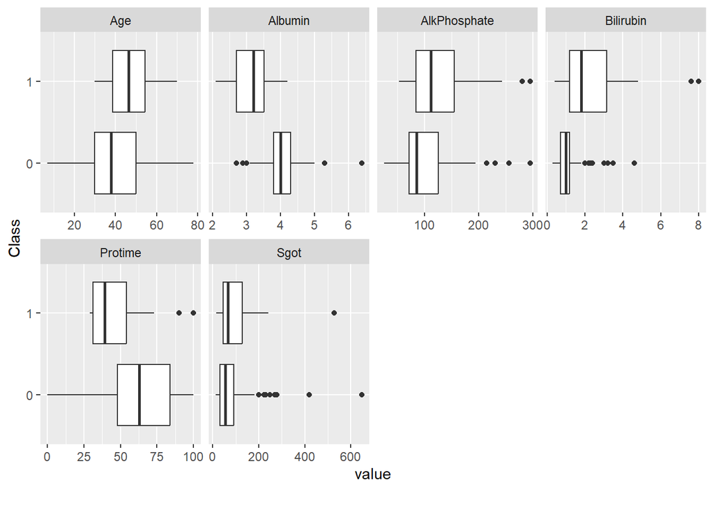

```r
plot_boxplot(df5, by = "Class")
```

## 3.6. Correlation

We can see that correlation matrices for different methods are very similar. We also added a matrix for initial data with omitting objects with missing values.

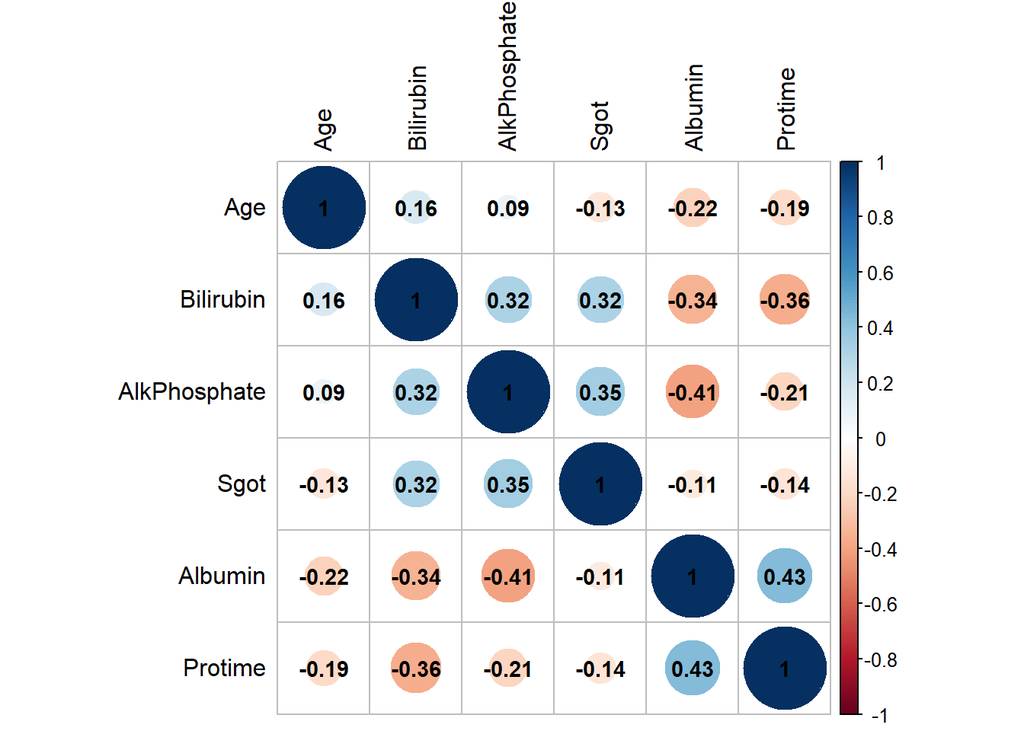

```r
df_omit <- na.omit(df)
cor_matrix1 <- cor(df_omit[, sapply(df_omit, is.numeric)], method = "pearson")
cor_matrix2 <- cor(df2[, sapply(df2, is.numeric)], method = "pearson")
cor_matrix3 <- cor(df5[, sapply(df5, is.numeric)], method = "pearson")

corrplot(cor_matrix1, tl.col = "black", addCoef.col = 1, number.cex = 0.9)
```

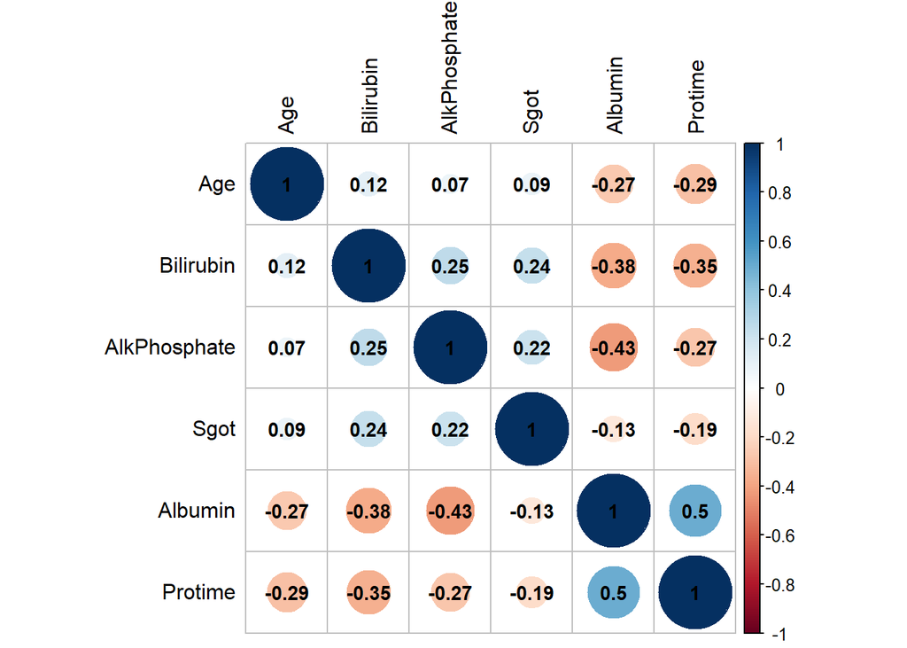

```r
corrplot(cor_matrix2, tl.col = "black", addCoef.col = 1, number.cex = 0.9)
```

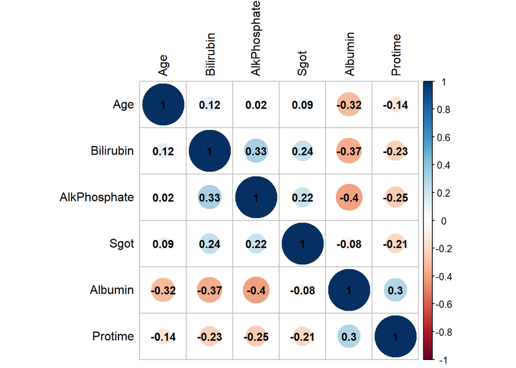

```r
corrplot(cor_matrix3, tl.col = "black", addCoef.col = 1, number.cex = 0.9)
```

# 4. Classification

## 4.6. Logistic regression (LR)

```r
summary(model.logit1)
```

```
##
## Call:
## glm(formula = Class ~ . - Class, family = binomial(link = "logit"),
##     data = train.balanced1)
##
## Coefficients:
##                  Estimate Std. Error z value Pr(>|z|)
## (Intercept)    -2.030e+01  1.561e+03  -0.013  0.98963
## Age             1.152e-01  4.866e-02   2.367  0.01794 *
## Sex             2.046e+01  1.561e+03   0.013  0.98954
## Steroid         3.580e+00  1.369e+00   2.615  0.00892 **
## Antivirals     -9.730e-01  1.688e+00  -0.577  0.56426
## Fatigue         1.686e+00  1.590e+00   1.060  0.28895
## Malaise         1.142e+00  1.154e+00   0.989  0.32244
## Anorexia       -3.738e+00  1.182e+00  -3.163  0.00156 **
## LiverBig       -1.809e+00  1.596e+00  -1.134  0.25684
## LiverFirm      -5.856e-01  1.114e+00  -0.526  0.59918
## SpleenPalpable  3.086e-01  1.094e+00   0.282  0.77779
## Spiders         2.605e+00  1.153e+00   2.259  0.02388 *
## Ascites         7.618e-01  1.770e+00   0.430  0.66697
## Varices        -4.583e-01  1.534e+00  -0.299  0.76509
## Bilirubin       1.254e+00  4.536e-01   2.764  0.00571 **
## AlkPhosphate   -2.814e-03  7.666e-03  -0.367  0.71360
## Sgot           -2.227e-03  6.193e-03  -0.360  0.71914
## Albumin        -2.050e+00  1.123e+00  -1.826  0.06784 .
## Protime        -8.527e-02  3.647e-02  -2.338  0.01940 *
## Histology       1.289e+00  9.392e-01   1.372  0.17003
## ---
## Signif. codes:  0 '***' 0.001 '**' 0.01 '*' 0.05 '.' 0.1 ' ' 1
##
## (Dispersion parameter for binomial family taken to be 1)
##
##     Null deviance: 257.851  on 185  degrees of freedom
## Residual deviance:  68.755  on 166  degrees of freedom
## AIC: 108.76
##
## Number of Fisher Scoring iterations: 17
```

```r
summary(model.logit2)
```

```
##
## Call:
## glm(formula = Class ~ . - Class, family = binomial(link = "logit"),
##     data = train.balanced2)
##
## Coefficients:
##                  Estimate Std. Error z value Pr(>|z|)
## (Intercept)    -2.419e+01  1.684e+03  -0.014  0.98854
## Age             8.595e-02  4.121e-02   2.086  0.03700 *
## Sex             1.902e+01  1.684e+03   0.011  0.99099
## Steroid         2.484e+00  1.067e+00   2.328  0.01991 *
## Antivirals     -7.505e-01  1.333e+00  -0.563  0.57341
## Fatigue         3.549e-01  1.289e+00   0.275  0.78310
## Malaise         1.064e+00  1.082e+00   0.983  0.32570
## Anorexia       -2.753e+00  1.000e+00  -2.753  0.00591 **
## LiverBig       -1.894e+00  1.127e+00  -1.680  0.09286 .
## LiverFirm       3.556e-01  9.451e-01   0.376  0.70678
## SpleenPalpable  9.053e-01  1.033e+00   0.876  0.38087
## Spiders         1.112e+00  9.134e-01   1.217  0.22363
## Ascites         2.711e+00  1.330e+00   2.038  0.04156 *
## Varices        -5.952e-02  1.166e+00  -0.051  0.95928
## Bilirubin       1.131e+00  4.387e-01   2.578  0.00995 **
## AlkPhosphate    9.912e-03  7.006e-03   1.415  0.15713
## Sgot           -1.912e-04  4.243e-03  -0.045  0.96406
## Albumin        -5.053e-01  8.137e-01  -0.621  0.53456
## Protime        -5.367e-02  2.320e-02  -2.313  0.02073 *
## Histology      -3.479e-02  7.806e-01  -0.045  0.96445
## ---
## Signif. codes:  0 '***' 0.001 '**' 0.01 '*' 0.05 '.' 0.1 ' ' 1
##
## (Dispersion parameter for binomial family taken to be 1)
##
##     Null deviance: 257.851  on 185  degrees of freedom
## Residual deviance:  79.775  on 166  degrees of freedom
## AIC: 119.77
##
## Number of Fisher Scoring iterations: 17
```

```r
summary(model.logit3)
```

```
##
## Call:
## glm(formula = Class ~ . - Class, family = binomial(link = "logit"),
##     data = train.balanced3)
##
## Coefficients:
##                  Estimate Std. Error z value Pr(>|z|)
## (Intercept)    -1.857e+01  1.560e+03  -0.012   0.9905
## Age             4.959e-02  4.608e-02   1.076   0.2819
## Sex             1.911e+01  1.560e+03   0.012   0.9902
## Steroid         1.585e+00  1.117e+00   1.419   0.1558
## Antivirals      1.857e+00  1.429e+00   1.299   0.1939
## Fatigue         1.431e+00  1.684e+00   0.850   0.3955
## Malaise         1.811e+00  1.115e+00   1.624   0.1043
## Anorexia       -3.516e+00  1.409e+00  -2.496   0.0125 *
## LiverBig        6.857e-01  1.247e+00   0.550   0.5822
## LiverFirm      -1.942e+00  1.583e+00  -1.227   0.2198
## SpleenPalpable  9.144e-01  1.103e+00   0.829   0.4069
## Spiders         1.827e+00  1.001e+00   1.825   0.0681 .
## Ascites         2.102e+00  1.327e+00   1.584   0.1131
## Varices         4.188e-01  1.241e+00   0.337   0.7358
## Bilirubin       1.418e+00  5.844e-01   2.427   0.0152 *
## AlkPhosphate   -6.290e-03  9.502e-03  -0.662   0.5080
## Sgot            6.720e-03  4.844e-03   1.387   0.1653
## Albumin        -2.696e+00  1.082e+00  -2.491   0.0127 *
## Protime         1.468e-02  2.790e-02   0.526   0.5988
## Histology      -4.628e-01  9.276e-01  -0.499   0.6178
## ---
## Signif. codes:  0 '***' 0.001 '**' 0.01 '*' 0.05 '.' 0.1 ' ' 1
##
## (Dispersion parameter for binomial family taken to be 1)
##
##     Null deviance: 257.851  on 185  degrees of freedom
## Residual deviance:  71.801  on 166  degrees of freedom
## AIC: 111.8
##
## Number of Fisher Scoring iterations: 17
```

```r
summary(model.logit4)
```

```
##
## Call:
## glm(formula = Class ~ . - Class - Age - Anorexia - Bilirubin,
##     family = binomial(link = "logit"), data = train.balanced1)
##
## Coefficients:
##                  Estimate Std. Error z value Pr(>|z|)
## (Intercept)    -1.397e+01  1.805e+03  -0.008   0.9938
## Sex             1.865e+01  1.805e+03   0.010   0.9918
## Steroid         1.425e+00  7.365e-01   1.935   0.0530 .
## Antivirals      4.030e-02  1.017e+00   0.040   0.9684
## Fatigue         2.026e+00  1.291e+00   1.569   0.1166
## Malaise         8.756e-01  8.106e-01   1.080   0.2801
## LiverBig       -7.743e-01  9.587e-01  -0.808   0.4193
## LiverFirm      -6.358e-01  7.415e-01  -0.857   0.3912
## SpleenPalpable  1.275e+00  8.195e-01   1.555   0.1199
## Spiders         1.076e+00  6.875e-01   1.565   0.1175
## Ascites         1.146e+00  1.118e+00   1.026   0.3050
## Varices        -4.592e-01  1.070e+00  -0.429   0.6678
## AlkPhosphate    4.040e-04  5.868e-03   0.069   0.9451
## Sgot           -2.156e-03  3.223e-03  -0.669   0.5035
## Albumin        -1.669e+00  7.459e-01  -2.238   0.0253 *
## Protime        -4.044e-02  1.913e-02  -2.114   0.0346 *
## Histology       9.870e-03  7.066e-01   0.014   0.9889
## ---
## Signif. codes:  0 '***' 0.001 '**' 0.01 '*' 0.05 '.' 0.1 ' ' 1
##
## (Dispersion parameter for binomial family taken to be 1)
##
##     Null deviance: 257.85  on 185  degrees of freedom
## Residual deviance: 101.14  on 169  degrees of freedom
## AIC: 135.14
##
## Number of Fisher Scoring iterations: 17
```

```r
summary(model.logit5)
```

```
##
## Call:
## glm(formula = Class ~ . - Class - Age - Anorexia - Bilirubin,
##     family = binomial(link = "logit"), data = train.balanced2)
##
## Coefficients:
##                  Estimate Std. Error z value Pr(>|z|)
## (Intercept)    -1.357e+01  1.738e+03  -0.008  0.99377
## Sex             1.871e+01  1.738e+03   0.011  0.99141
## Steroid         1.182e+00  7.307e-01   1.618  0.10575
## Antivirals     -5.719e-01  1.105e+00  -0.518  0.60464
## Fatigue         9.768e-01  1.124e+00   0.869  0.38473
## Malaise         8.048e-01  8.142e-01   0.988  0.32294
## LiverBig       -1.136e+00  8.647e-01  -1.314  0.18898
## LiverFirm       4.764e-01  7.315e-01   0.651  0.51491
## SpleenPalpable  9.117e-01  8.014e-01   1.138  0.25524
## Spiders         6.444e-01  6.896e-01   0.934  0.35006
## Ascites         1.438e+00  1.063e+00   1.353  0.17616
## Varices        -5.385e-01  9.528e-01  -0.565  0.57192
## AlkPhosphate    5.640e-03  5.762e-03   0.979  0.32766
## Sgot           -1.116e-03  3.206e-03  -0.348  0.72768
## Albumin        -1.430e+00  7.018e-01  -2.037  0.04161 *
## Protime        -5.708e-02  1.942e-02  -2.939  0.00329 **
## Histology      -6.452e-01  6.428e-01  -1.004  0.31546
## ---
## Signif. codes:  0 '***' 0.001 '**' 0.01 '*' 0.05 '.' 0.1 ' ' 1
##
## (Dispersion parameter for binomial family taken to be 1)
##
##     Null deviance: 257.85  on 185  degrees of freedom
## Residual deviance: 102.09  on 169  degrees of freedom
## AIC: 136.09
##
## Number of Fisher Scoring iterations: 17
```

```r
summary(model.logit6)
```

```
##
## Call:
## glm(formula = Class ~ . - Class - Age - Anorexia - Bilirubin,
##     family = binomial(link = "logit"), data = train.balanced3)
##
## Coefficients:
##                  Estimate Std. Error z value Pr(>|z|)
## (Intercept)    -1.015e+01  1.839e+03  -0.006  0.99560
## Sex             1.777e+01  1.839e+03   0.010  0.99229
## Steroid         8.657e-01  8.475e-01   1.022  0.30699
## Antivirals      9.319e-01  1.135e+00   0.821  0.41148
## Fatigue         1.079e+00  1.445e+00   0.747  0.45496
## Malaise         1.376e+00  9.495e-01   1.449  0.14725
## LiverBig        6.535e-01  9.561e-01   0.684  0.49428
## LiverFirm      -5.168e-01  9.734e-01  -0.531  0.59543
## SpleenPalpable  1.808e+00  7.930e-01   2.279  0.02264 *
## Spiders         1.222e+00  7.889e-01   1.549  0.12150
## Ascites         9.997e-01  1.015e+00   0.985  0.32458
## Varices         5.655e-01  1.037e+00   0.545  0.58548
## AlkPhosphate   -1.740e-02  8.130e-03  -2.140  0.03235 *
## Sgot            4.508e-03  3.689e-03   1.222  0.22176
## Albumin        -2.464e+00  7.798e-01  -3.159  0.00158 **
## Protime        -2.208e-02  1.816e-02  -1.216  0.22399
## Histology      -7.392e-01  7.447e-01  -0.993  0.32090
## ---
## Signif. codes:  0 '***' 0.001 '**' 0.01 '*' 0.05 '.' 0.1 ' ' 1
##
## (Dispersion parameter for binomial family taken to be 1)
##
##     Null deviance: 257.851  on 185  degrees of freedom
## Residual deviance:  88.159  on 169  degrees of freedom
## AIC: 122.16
##
## Number of Fisher Scoring iterations: 17
```

```r
summary(model.logit7)
```

```
##
## Call:
## glm(formula = Class ~ . - Class - Age - Steroid - AlkPhosphate -
##     Sgot, family = binomial(link = "logit"), data = train.balanced1)
##
## Coefficients:
##                  Estimate Std. Error z value Pr(>|z|)
## (Intercept)     -13.75786 1709.38618  -0.008 0.993578
## Sex              18.83603 1709.38375   0.011 0.991208
## Antivirals        0.12920    1.17947   0.110 0.912773
## Fatigue           1.76994    1.24643   1.420 0.155607
## Malaise           1.95626    0.81782   2.392 0.016755 *
## Anorexia         -2.78879    0.83408  -3.344 0.000827 ***
## LiverBig         -0.75707    1.13804  -0.665 0.505896
## LiverFirm        -1.28415    0.88930  -1.444 0.148738
## SpleenPalpable    1.39971    0.86055   1.627 0.103837
## Spiders           1.62689    0.82982   1.961 0.049933 *
## Ascites           0.19876    1.25332   0.159 0.873993
## Varices          -1.27272    1.10776  -1.149 0.250594
## Bilirubin         0.82404    0.31897   2.583 0.009782 **
## Albumin          -1.84133    0.82090  -2.243 0.024893 *
## Protime          -0.03951    0.02197  -1.798 0.072149 .
## Histology         0.30671    0.77655   0.395 0.692874
## ---
## Signif. codes:  0 '***' 0.001 '**' 0.01 '*' 0.05 '.' 0.1 ' ' 1
##
## (Dispersion parameter for binomial family taken to be 1)
##
##     Null deviance: 257.851  on 185  degrees of freedom
## Residual deviance:  84.748  on 170  degrees of freedom
## AIC: 116.75
##
## Number of Fisher Scoring iterations: 17
```

```r
summary(model.logit8)
```

```
##
## Call:
## glm(formula = Class ~ . - Class - Age - Steroid - AlkPhosphate -
##     Sgot, family = binomial(link = "logit"), data = train.balanced2)
##
## Coefficients:
##                  Estimate Std. Error z value Pr(>|z|)
## (Intercept)     -13.18976 1746.02601  -0.008  0.99397
## Sex              18.34547 1746.02399   0.011  0.99162
## Antivirals       -0.19893    1.11282  -0.179  0.85813
## Fatigue           0.43351    1.02379   0.423  0.67198
## Malaise           1.95153    0.82374   2.369  0.01783 *
## Anorexia         -2.25367    0.81783  -2.756  0.00586 **
## LiverBig         -1.29737    0.94044  -1.380  0.16773
## LiverFirm         0.32007    0.77771   0.412  0.68067
## SpleenPalpable    1.41388    0.80998   1.746  0.08089 .
## Spiders           0.69000    0.78797   0.876  0.38121
## Ascites           0.71461    1.05508   0.677  0.49821
## Varices          -1.10167    0.89232  -1.235  0.21698
## Bilirubin         0.87276    0.34418   2.536  0.01122 *
## Albumin          -1.47049    0.71813  -2.048  0.04059 *
## Protime          -0.04765    0.01868  -2.550  0.01076 *
## Histology        -0.52041    0.68098  -0.764  0.44474
## ---
## Signif. codes:  0 '***' 0.001 '**' 0.01 '*' 0.05 '.' 0.1 ' ' 1
##
## (Dispersion parameter for binomial family taken to be 1)
##
##     Null deviance: 257.851  on 185  degrees of freedom
## Residual deviance:  91.399  on 170  degrees of freedom
## AIC: 123.4
##
## Number of Fisher Scoring iterations: 17
```

```r
summary(model.logit9)
```

```
##
## Call:
## glm(formula = Class ~ . - Class - Age - Steroid - AlkPhosphate -
##     Sgot, family = binomial(link = "logit"), data = train.balanced3)
##
## Coefficients:
##                  Estimate Std. Error z value Pr(>|z|)
## (Intercept)    -1.401e+01  1.580e+03  -0.009  0.99293
## Sex             1.889e+01  1.580e+03   0.012  0.99046
## Antivirals      1.402e+00  1.247e+00   1.125  0.26071
## Fatigue         1.065e+00  1.422e+00   0.749  0.45388
## Malaise         2.389e+00  9.812e-01   2.435  0.01491 *
## Anorexia       -2.497e+00  9.274e-01  -2.693  0.00708 **
## LiverBig        6.493e-01  1.094e+00   0.594  0.55272
## LiverFirm      -1.461e+00  1.096e+00  -1.332  0.18273
## SpleenPalpable  1.510e+00  9.491e-01   1.591  0.11152
## Spiders         1.319e+00  8.945e-01   1.474  0.14042
## Ascites         1.124e+00  1.053e+00   1.067  0.28580
## Varices        -1.307e+00  9.719e-01  -1.345  0.17877
## Bilirubin       1.296e+00  4.412e-01   2.938  0.00330 **
## Albumin        -2.712e+00  9.037e-01  -3.001  0.00269 **
## Protime         7.681e-03  1.903e-02   0.404  0.68648
## Histology      -1.059e+00  7.851e-01  -1.349  0.17743
## ---
## Signif. codes:  0 '***' 0.001 '**' 0.01 '*' 0.05 '.' 0.1 ' ' 1
##
## (Dispersion parameter for binomial family taken to be 1)
##
##     Null deviance: 257.851  on 185  degrees of freedom
## Residual deviance:  78.127  on 170  degrees of freedom
## AIC: 110.13
##
## Number of Fisher Scoring iterations: 17
```

We can see confusion matrices for all models. The results are pretty similar.

```r
confusionMatrix(table(pred.labels1, real.labels), positive = "1")
```

```
## Confusion Matrix and Statistics
##
##             real.labels
## pred.labels1  0  1
##            0 28  3
##            1  2  5
##
##                Accuracy : 0.8684
##                  95% CI : (0.7191, 0.9559)
##     No Information Rate : 0.7895
##     P-Value [Acc > NIR] : 0.1596
##
##                   Kappa : 0.5852
##
##  Mcnemar's Test P-Value : 1.0000
##
##             Sensitivity : 0.6250
##             Specificity : 0.9333
##          Pos Pred Value : 0.7143
##          Neg Pred Value : 0.9032
##              Prevalence : 0.2105
##          Detection Rate : 0.1316
##    Detection Prevalence : 0.1842
##       Balanced Accuracy : 0.7792
##
##        'Positive' Class : 1
##
```

```r
confusionMatrix(table(pred.labels2, real.labels), positive = "1")
```

```
## Confusion Matrix and Statistics
##
##             real.labels
## pred.labels2  0  1
##            0 28  2
##            1  2  6
##
##                Accuracy : 0.8947
##                  95% CI : (0.752, 0.9706)
##     No Information Rate : 0.7895
##     P-Value [Acc > NIR] : 0.07462
##
##                   Kappa : 0.6833
##
##  Mcnemar's Test P-Value : 1.00000
##
##             Sensitivity : 0.7500
##             Specificity : 0.9333
##          Pos Pred Value : 0.7500
##          Neg Pred Value : 0.9333
##              Prevalence : 0.2105
##          Detection Rate : 0.1579
##    Detection Prevalence : 0.2105
##       Balanced Accuracy : 0.8417
##
##        'Positive' Class : 1
##
```

```r
confusionMatrix(table(pred.labels3, real.labels), positive = "1")
```

```
## Confusion Matrix and Statistics
##
##             real.labels
## pred.labels3  0  1
##            0 28  2
##            1  2  6
##
##                Accuracy : 0.8947
##                  95% CI : (0.752, 0.9706)
##     No Information Rate : 0.7895
##     P-Value [Acc > NIR] : 0.07462
##
##                   Kappa : 0.6833
##
##  Mcnemar's Test P-Value : 1.00000
##
##             Sensitivity : 0.7500
##             Specificity : 0.9333
##          Pos Pred Value : 0.7500
##          Neg Pred Value : 0.9333
##              Prevalence : 0.2105
##          Detection Rate : 0.1579
##    Detection Prevalence : 0.2105
##       Balanced Accuracy : 0.8417
##
##        'Positive' Class : 1
##
```

```r
confusionMatrix(table(pred.labels4, real.labels), positive = "1")
```

```
## Confusion Matrix and Statistics
##
##             real.labels
## pred.labels4  0  1
##            0 29  2
##            1  1  6
##
##                Accuracy : 0.9211
##                  95% CI : (0.7862, 0.9834)
##     No Information Rate : 0.7895
##     P-Value [Acc > NIR] : 0.02776
##
##                   Kappa : 0.7511
##
##  Mcnemar's Test P-Value : 1.00000
##
##             Sensitivity : 0.7500
##             Specificity : 0.9667
##          Pos Pred Value : 0.8571
##          Neg Pred Value : 0.9355
##              Prevalence : 0.2105
##          Detection Rate : 0.1579
##    Detection Prevalence : 0.1842
##       Balanced Accuracy : 0.8583
##
##        'Positive' Class : 1
##
```

```r
confusionMatrix(table(pred.labels5, real.labels), positive = "1")
```

```
## Confusion Matrix and Statistics
##
##             real.labels
## pred.labels5  0  1
##            0 28  2
##            1  2  6
##
##                Accuracy : 0.8947
##                  95% CI : (0.752, 0.9706)
##     No Information Rate : 0.7895
##     P-Value [Acc > NIR] : 0.07462
##
##                   Kappa : 0.6833
##
##  Mcnemar's Test P-Value : 1.00000
##
##             Sensitivity : 0.7500
##             Specificity : 0.9333
##          Pos Pred Value : 0.7500
##          Neg Pred Value : 0.9333
##              Prevalence : 0.2105
##          Detection Rate : 0.1579
##    Detection Prevalence : 0.2105
##       Balanced Accuracy : 0.8417
##
##        'Positive' Class : 1
##
```

```r
confusionMatrix(table(pred.labels6, real.labels), positive = "1")
```

```
## Confusion Matrix and Statistics
##
##             real.labels
## pred.labels6  0  1
##            0 28  2
##            1  2  6
##
##                Accuracy : 0.8947
##                  95% CI : (0.752, 0.9706)
##     No Information Rate : 0.7895
##     P-Value [Acc > NIR] : 0.07462
##
##                   Kappa : 0.6833
##
##  Mcnemar's Test P-Value : 1.00000
##
##             Sensitivity : 0.7500
##             Specificity : 0.9333
##          Pos Pred Value : 0.7500
##          Neg Pred Value : 0.9333
##              Prevalence : 0.2105
##          Detection Rate : 0.1579
##    Detection Prevalence : 0.2105
##       Balanced Accuracy : 0.8417
##
##        'Positive' Class : 1
##
```

```r
confusionMatrix(table(pred.labels7, real.labels), positive = "1")
```

```
## Confusion Matrix and Statistics
##
##             real.labels
## pred.labels7  0  1
##            0 27  2
##            1  3  6
##
##                Accuracy : 0.8684
##                  95% CI : (0.7191, 0.9559)
##     No Information Rate : 0.7895
##     P-Value [Acc > NIR] : 0.1596
##
##                   Kappa : 0.6215
##
##  Mcnemar's Test P-Value : 1.0000
##
##             Sensitivity : 0.7500
##             Specificity : 0.9000
##          Pos Pred Value : 0.6667
##          Neg Pred Value : 0.9310
##              Prevalence : 0.2105
##          Detection Rate : 0.1579
##    Detection Prevalence : 0.2368
##       Balanced Accuracy : 0.8250
##
##        'Positive' Class : 1
##
```

```r
confusionMatrix(table(pred.labels8, real.labels), positive = "1")
```

```
## Confusion Matrix and Statistics
##
##             real.labels
## pred.labels8  0  1
##            0 27  2
##            1  3  6
##
##                Accuracy : 0.8684
##                  95% CI : (0.7191, 0.9559)
##     No Information Rate : 0.7895
##     P-Value [Acc > NIR] : 0.1596
##
##                   Kappa : 0.6215
##
##  Mcnemar's Test P-Value : 1.0000
##
##             Sensitivity : 0.7500
##             Specificity : 0.9000
##          Pos Pred Value : 0.6667
##          Neg Pred Value : 0.9310
##              Prevalence : 0.2105
##          Detection Rate : 0.1579
##    Detection Prevalence : 0.2368
##       Balanced Accuracy : 0.8250
##
##        'Positive' Class : 1
##
```

```r
confusionMatrix(table(pred.labels9, real.labels), positive = "1")
```

```
## Confusion Matrix and Statistics
##
##             real.labels
## pred.labels9  0  1
##            0 29  2
##            1  1  6
##
##                Accuracy : 0.9211
##                  95% CI : (0.7862, 0.9834)
##     No Information Rate : 0.7895
##     P-Value [Acc > NIR] : 0.02776
##
##                   Kappa : 0.7511
##
##  Mcnemar's Test P-Value : 1.00000
##
##             Sensitivity : 0.7500
##             Specificity : 0.9667
##          Pos Pred Value : 0.8571
##          Neg Pred Value : 0.9355
##              Prevalence : 0.2105
##          Detection Rate : 0.1579
##    Detection Prevalence : 0.1842
##       Balanced Accuracy : 0.8583
##
##        'Positive' Class : 1
##
```

## 4.7. Random tree

We can see that full trees for different models and different datasets (for different imputation methods) are pretty different.

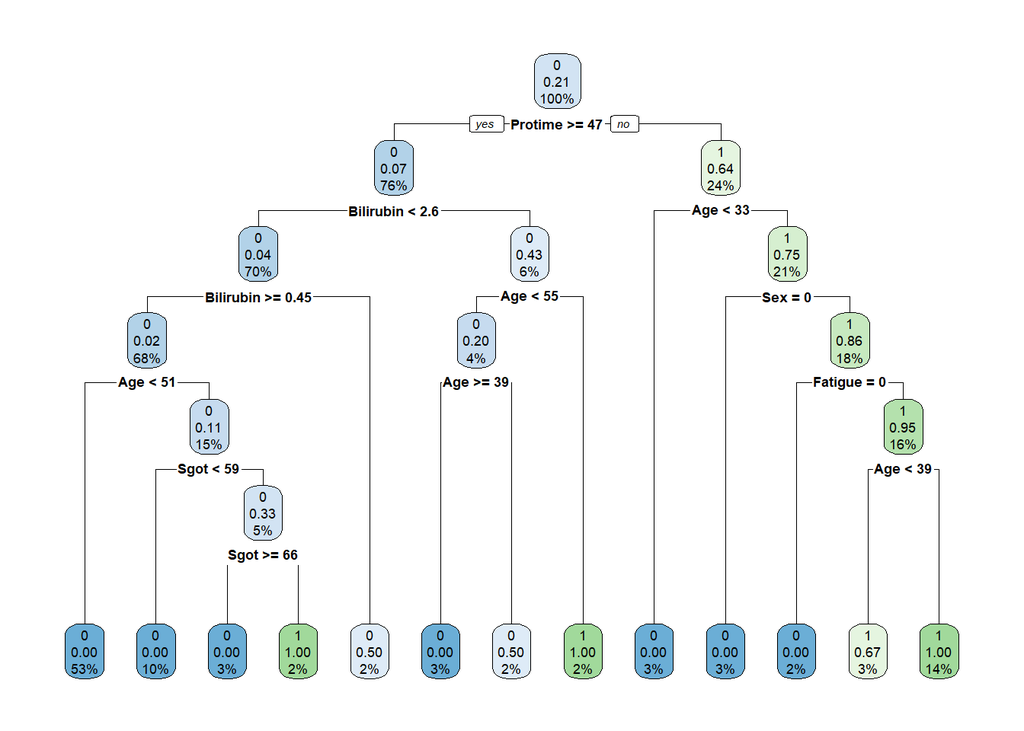

```r
rpart.plot(full.tree1)
```

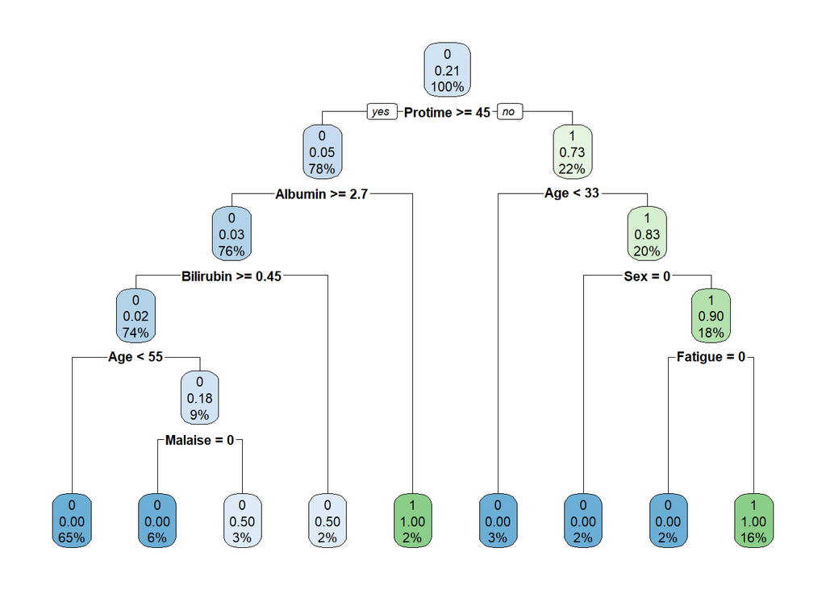

```r
rpart.plot(full.tree2)
```

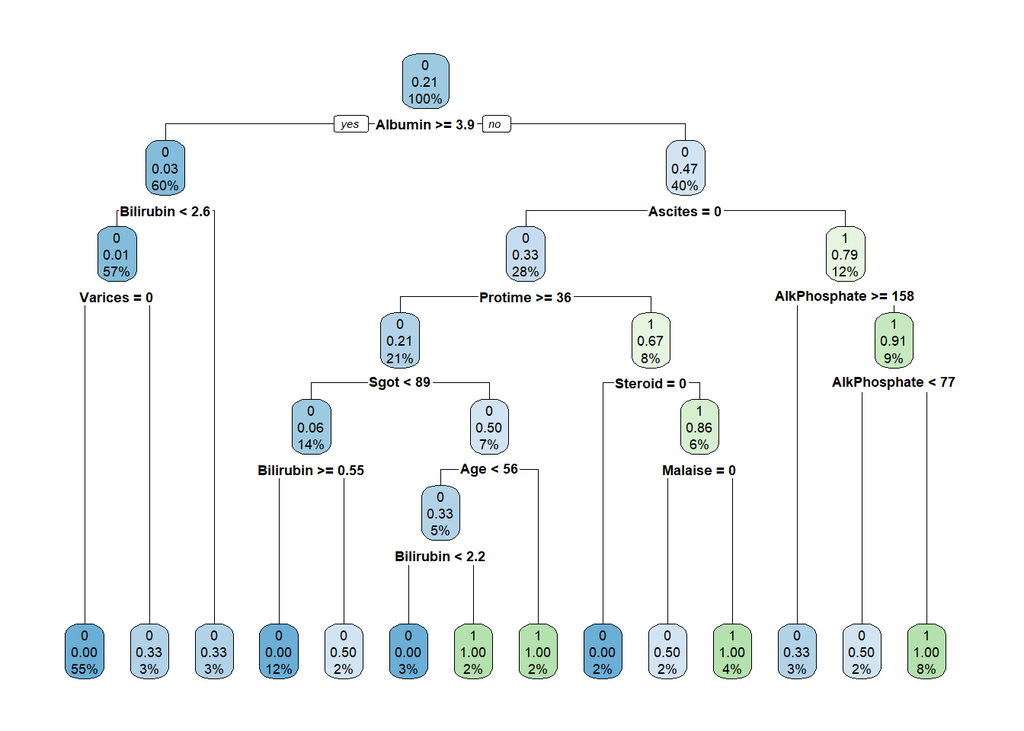

```r
rpart.plot(full.tree3)
```

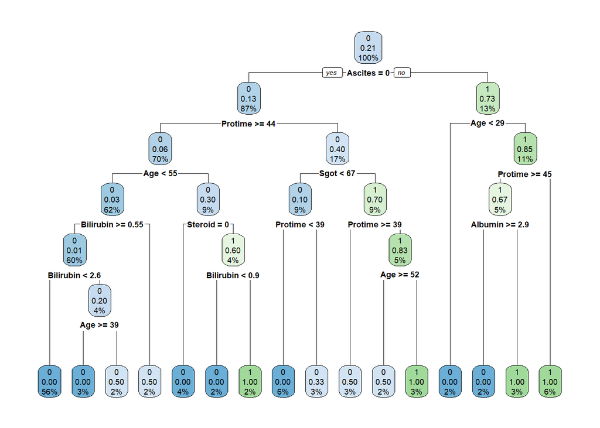

```r
rpart.plot(full.tree4)
```

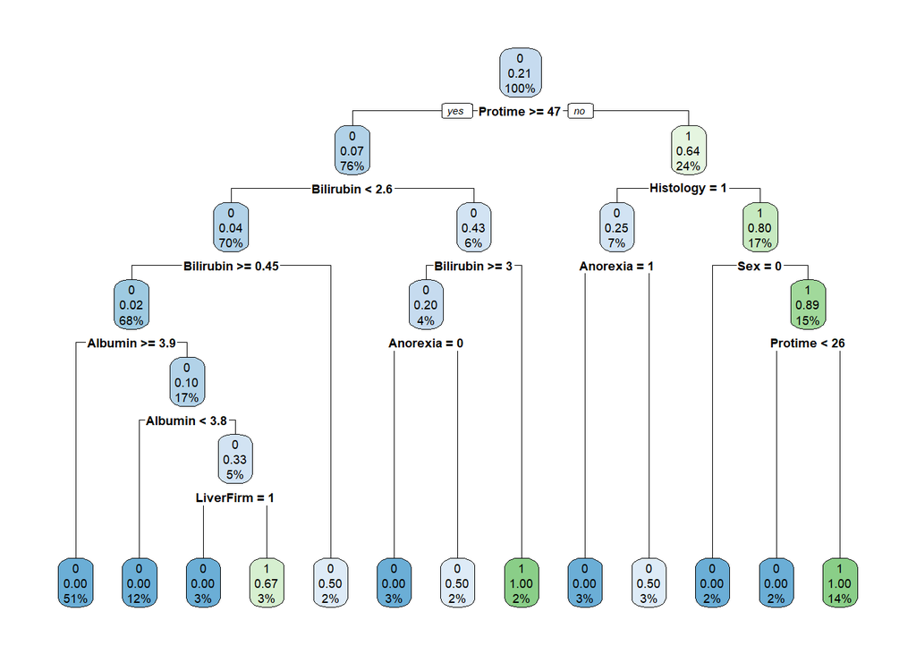

```r
rpart.plot(full.tree5)
```

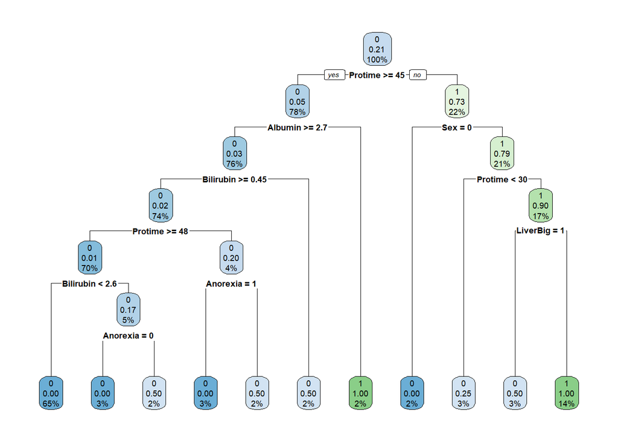

```r
rpart.plot(full.tree6)
```

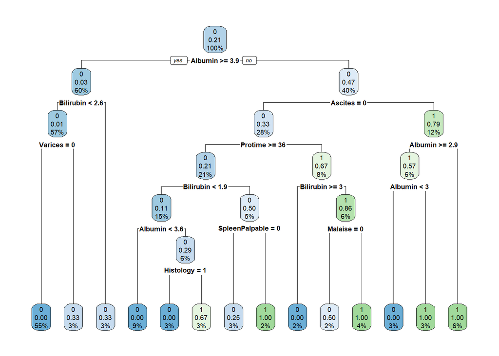

```r
rpart.plot(full.tree7)
```

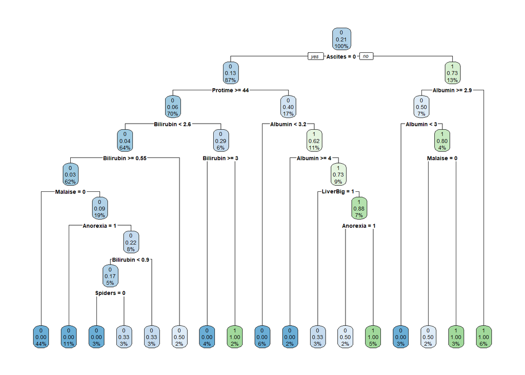

```r
rpart.plot(full.tree8)
```

We can see plots and information about misclassification error.

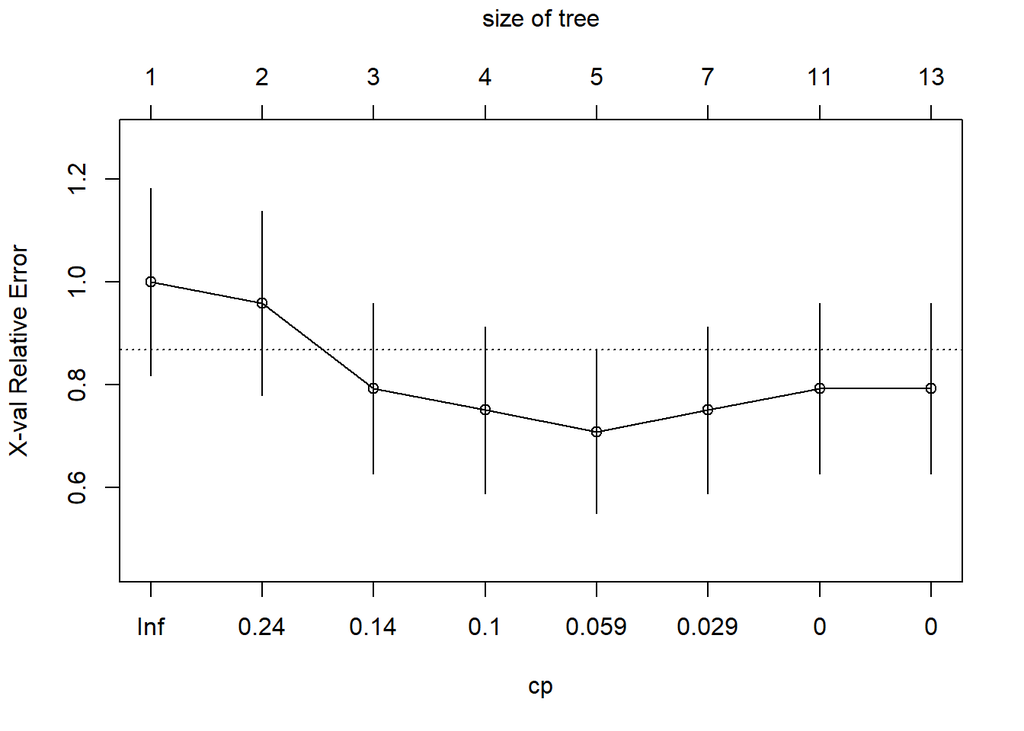

```r
plotcp(full.tree1)
```

```r
printcp(full.tree1)
```

```
##
## Classification tree:
## rpart(formula = mod1, data = train1, control = rpart.control(cp = -1,
##     minsplit = 5))
##
## Variables actually used in tree construction:
## [1] Age       Bilirubin Fatigue   Protime   Sex       Sgot
##
## Root node error: 24/117 = 0.20513
##
## n= 117
##
##          CP nsplit rel error  xerror    xstd
## 1  0.333333      0   1.00000 1.00000 0.18199
## 2  0.166667      1   0.66667 0.95833 0.17911
## 3  0.125000      2   0.50000 0.79167 0.16622
## 4  0.083333      3   0.37500 0.75000 0.16261
## 5  0.041667      4   0.29167 0.70833 0.15883
## 6  0.020833      6   0.20833 0.75000 0.16261
## 7  0.000000     10   0.12500 0.79167 0.16622
## 8 -1.000000     12   0.12500 0.79167 0.16622
```

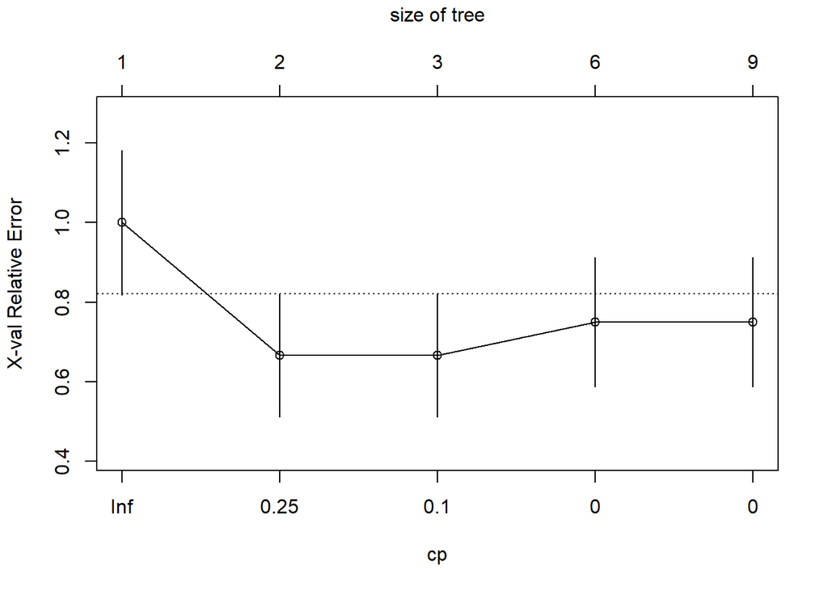

```r
plotcp(full.tree2)
```

```r
printcp(full.tree2)
```

```
##
## Classification tree:
## rpart(formula = mod1, data = train2, control = rpart.control(cp = -1,
##     minsplit = 5))
##
## Variables actually used in tree construction:
## [1] Age       Albumin   Bilirubin Fatigue   Malaise   Protime   Sex
##
## Root node error: 24/117 = 0.20513
##
## n= 117
##
##          CP nsplit rel error  xerror    xstd
## 1  0.500000      0     1.000 1.00000 0.18199
## 2  0.125000      1     0.500 0.66667 0.15485
## 3  0.083333      2     0.375 0.66667 0.15485
## 4  0.000000      5     0.125 0.75000 0.16261
## 5 -1.000000      8     0.125 0.75000 0.16261
```

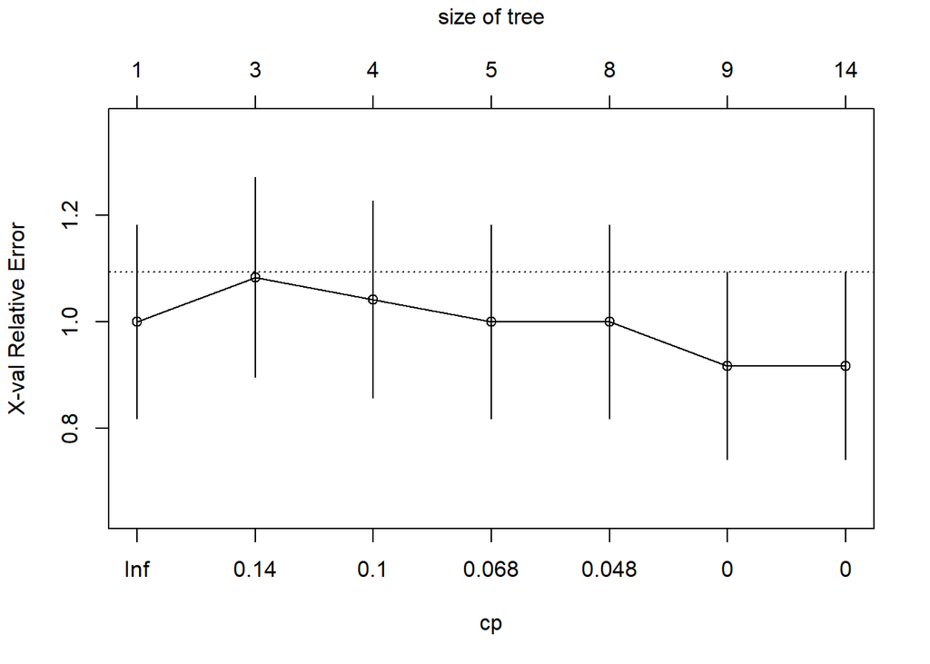

```r
plotcp(full.tree3)
```

```r
printcp(full.tree3)
```

```
##
## Classification tree:
## rpart(formula = mod1, data = train3, control = rpart.control(cp = -1,
##     minsplit = 5))
##
## Variables actually used in tree construction:
##  [1] Age          Albumin      AlkPhosphate Ascites      Bilirubin
##  [6] Malaise      Protime      Sgot         Steroid      Varices
##
## Root node error: 24/117 = 0.20513
##
## n= 117
##
##          CP nsplit rel error  xerror    xstd
## 1  0.166667      0   1.00000 1.00000 0.18199
## 2  0.125000      2   0.66667 1.08333 0.18737
## 3  0.083333      3   0.54167 1.04167 0.18474
## 4  0.055556      4   0.45833 1.00000 0.18199
## 5  0.041667      7   0.29167 1.00000 0.18199
## 6  0.000000      8   0.25000 0.91667 0.17610
## 7 -1.000000     13   0.25000 0.91667 0.17610
```

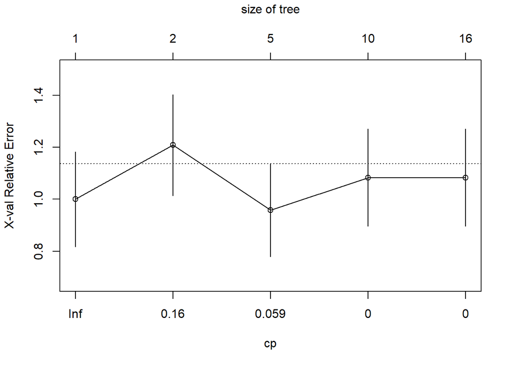

```r
plotcp(full.tree4)
```

```r
printcp(full.tree4)
```

```
##
## Classification tree:
## rpart(formula = mod1, data = train0, control = rpart.control(cp = -1,
##     minsplit = 5))
##
## Variables actually used in tree construction:
## [1] Age       Albumin   Ascites   Bilirubin Protime   Sgot      Steroid
##
## Root node error: 24/117 = 0.20513
##
## n= 117
##
##          CP nsplit rel error  xerror    xstd
## 1  0.291667      0   1.00000 1.00000 0.18199
## 2  0.083333      1   0.70833 1.20833 0.19460
## 3  0.041667      4   0.45833 0.95833 0.17911
## 4  0.000000      9   0.25000 1.08333 0.18737
## 5 -1.000000     15   0.25000 1.08333 0.18737
```

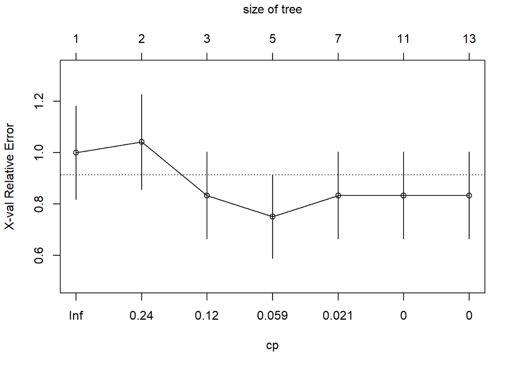

```r
plotcp(full.tree5)
```